# Practicum1

Thomas Faria

2024-06-05

## Part 1: Questions

### Question 1

```r
# Define dataframe
doc_df <- data.frame(
  doctor_type = c("PCP", "Psychiatrist", "Surgeon", "Anesthesia"),
  doctor_lastname = c("Smith", "Dame", "Jones", "Zayas"),
  location = c("MA", "ME", "NH", "VT"),
  AVG_Rating = c("7", "9", "8", "9")
)
print(doc_df)
```

```
##    doctor_type doctor_lastname location AVG_Rating
## 1          PCP           Smith       MA          7
## 2 Psychiatrist            Dame       ME          9
## 3      Surgeon           Jones       NH          8
## 4   Anesthesia           Zayas       VT          9
```

### Question 2

```r
# Index with brackets
doc_df[1, 2]
```

```
## [1] "Smith"
```

```r
doc_df[2:4, ]
```

```
##    doctor_type doctor_lastname location AVG_Rating
## 2 Psychiatrist            Dame       ME          9
## 3      Surgeon           Jones       NH          8
## 4   Anesthesia           Zayas       VT          9
```

```r
doc_df[, 4]
```

```
## [1] "7" "9" "8" "9"
```

### Question 3

```r
library(ggplot2)
head(mtcars)
```

```
##                    mpg cyl disp  hp drat    wt  qsec vs am gear carb
## Mazda RX4         21.0   6  160 110 3.90 2.620 16.46  0  1    4    4
## Mazda RX4 Wag     21.0   6  160 110 3.90 2.875 17.02  0  1    4    4
## Datsun 710        22.8   4  108  93 3.85 2.320 18.61  1  1    4    1
## Hornet 4 Drive    21.4   6  258 110 3.08 3.215 19.44  1  0    3    1
## Hornet Sportabout 18.7   8  360 175 3.15 3.440 17.02  0  0    3    2
## Valiant           18.1   6  225 105 2.76 3.460 20.22  1  0    3    1
```

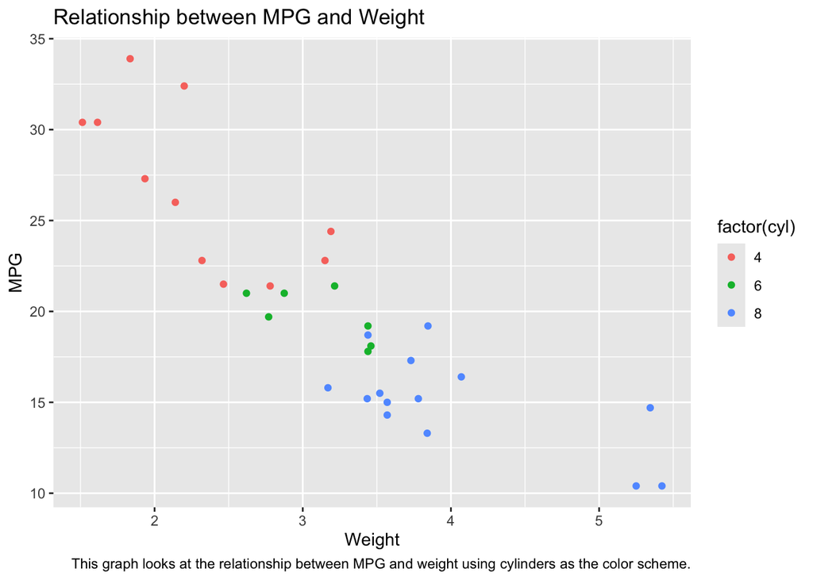

```r
ggplot(mtcars,aes(x=wt, y=mpg, color=factor(cyl))) + geom_point() + labs(x="Weight", y="MPG", title = "Relationship between MPG and Weight", caption = "This graph looks at the relationship between MPG and weight using cylinders as the color scheme.")
```

### Question 4

```r
# Examine variable summary stats
summary(mtcars)
```

```
##       mpg             cyl             disp             hp
##  Min.   :10.40   Min.   :4.000   Min.   : 71.1   Min.   : 52.0
##  1st Qu.:15.43   1st Qu.:4.000   1st Qu.:120.8   1st Qu.: 96.5
##  Median :19.20   Median :6.000   Median :196.3   Median :123.0
##  Mean   :20.09   Mean   :6.188   Mean   :230.7   Mean   :146.7
##  3rd Qu.:22.80   3rd Qu.:8.000   3rd Qu.:326.0   3rd Qu.:180.0
##  Max.   :33.90   Max.   :8.000   Max.   :472.0   Max.   :335.0
##       drat             wt             qsec             vs
##  Min.   :2.760   Min.   :1.513   Min.   :14.50   Min.   :0.0000
##  1st Qu.:3.080   1st Qu.:2.581   1st Qu.:16.89   1st Qu.:0.0000
##  Median :3.695   Median :3.325   Median :17.71   Median :0.0000
##  Mean   :3.597   Mean   :3.217   Mean   :17.85   Mean   :0.4375
##  3rd Qu.:3.920   3rd Qu.:3.610   3rd Qu.:18.90   3rd Qu.:1.0000
##  Max.   :4.930   Max.   :5.424   Max.   :22.90   Max.   :1.0000
##        am              gear            carb
##  Min.   :0.0000   Min.   :3.000   Min.   :1.000
##  1st Qu.:0.0000   1st Qu.:3.000   1st Qu.:2.000
##  Median :0.0000   Median :4.000   Median :2.000
##  Mean   :0.4062   Mean   :3.688   Mean   :2.812
##  3rd Qu.:1.0000   3rd Qu.:4.000   3rd Qu.:4.000
##  Max.   :1.0000   Max.   :5.000   Max.   :8.000
```

```r
mpg_weight_cor <- mtcars %>%
select(wt, mpg) %>%
drop_na() %>%
summarize(correlation = cor(wt, mpg))
mpg_weight_cor
```

```
##   correlation
## 1  -0.8676594
```

- It is known that the weight of a vehicle plays a key role in how fuel efficient it is, so both wt and mpg were selected to identify a potential correlation
- The Pearson coefficient is a descriptive statistic that reveals the linear correlation between two variables
- A value between 0 and 1 shows how strong the correlation is, with 1 indicating a strong correlation and 0 an absence of correlation
- The sign of the value indicates the type of correlation (positive or negative)
- In this case, the coefficient value returned is approximately -0.87, which indicates a strong, negative correlation
  - As vehicle weight increases, fuel efficiency (mpg) decreases

## Part 2: Practicum Tasks

#### Load data from provided URL

```r
# Documentation from data.world recommends package installation directly from Github
devtools::install_github("datadotworld/data.world-r", build_vignettes = TRUE)
```

```r
# Load the requisite API token obtained from data.world advanced settings (Thomas's account)
# Original code: token <- readLines('~/RStudioProjects/Summer24_DA5020_Group7_Practicum1/API_token')
# Changed
token <- readLines('API_token')
saved_cfg <- data.world::save_config(token)
data.world::set_config(saved_cfg)

# From data.world R and RStudio integration:
library("data.world")
sql_stmt <- data.world::qry_sql("SELECT * FROM chemical_dependence_treatment_program_admissions_beginning_2007_1")
query_results_df <- data.world::query(
  sql_stmt, "https://data.world/data-ny-gov/ngbt-9rwf")
```

#### Initial evaluation of dataset

- Determine necessary preparation steps and perform them
- Discuss distribution, outliers, and prepare summary stats

```r
# Evaluate data distribution, outliers, and prepare summary stats

# Reassign query results to more descriptive variable
admissions_data <- query_results_df

# Overview data
glimpse(admissions_data)
```

```
## Rows: 72,463
## Columns: 7
## $ year                       <dbl> 2017, 2017, 2017, 2017, 2017, 2017, 2017, 2…
## $ county_of_program_location <chr> "Albany", "Albany", "Albany", "Albany", "Al…
## $ program_category           <chr> "Crisis", "Crisis", "Crisis", "Crisis", "Cr…
## $ service_type               <chr> "Medically Managed Detoxification", "Medica…
## $ age_group                  <chr> "18 thru 24", "18 thru 24", "18 thru 24", "…
## $ primary_substance_group    <chr> "Alcohol", "All Others", "Cocaine incl Crac…
## $ admissions                 <dbl> 25, 7, 1, 64, 20, 140, 10, 4, 244, 63, 230,…
```

```r
summary(admissions_data)
```

```
##       year      county_of_program_location program_category
##  Min.   :2007   Length:72463               Length:72463
##  1st Qu.:2009   Class :character           Class :character
##  Median :2012   Mode  :character           Mode  :character
##  Mean   :2012
##  3rd Qu.:2015
##  Max.   :2017
##  service_type        age_group         primary_substance_group
##  Length:72463       Length:72463       Length:72463
##  Class :character   Class :character   Class :character
##  Mode  :character   Mode  :character   Mode  :character
##
##
##
##    admissions
##  Min.   :   1.00
##  1st Qu.:   3.00
##  Median :   8.00
##  Mean   :  44.62
##  3rd Qu.:  30.00
##  Max.   :2862.00
```

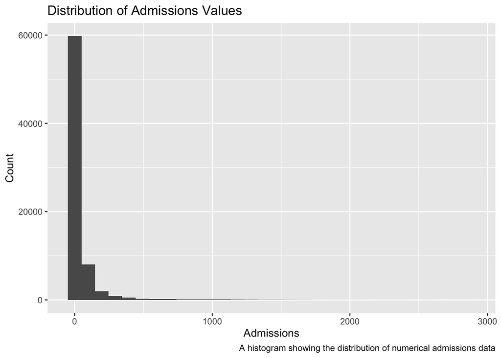

```r
# Visualize outliers in the admissions column
ggplot(admissions_data) +
  labs(title = "Admissions Data Distribution") +
  geom_histogram(mapping = aes(x = admissions), bindwidth = 5) +
  labs(title = "Distribution of Admissions Values",
       x = "Admissions",
       y = "Count",
       caption = "A histogram showing the distribution of numerical admissions data")
```

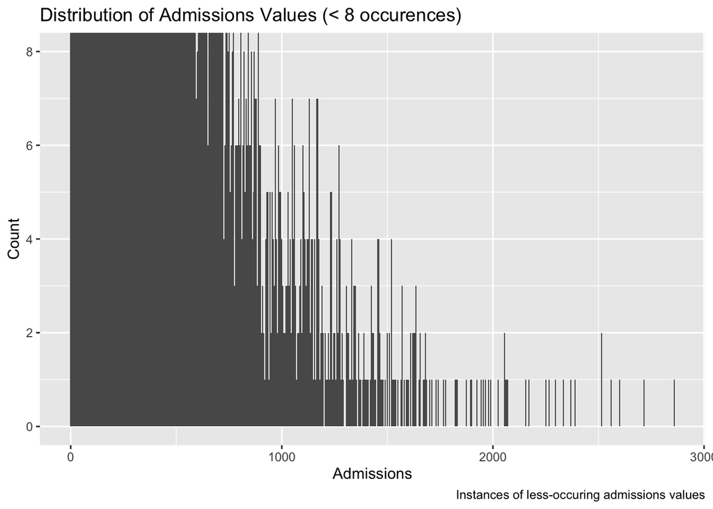

```r
# Zoom in on low occuring values
ggplot(admissions_data) +
  geom_histogram(mapping = aes(x = admissions), binwidth = 5) +
  labs(title = "Distribution of Admissions Values (< 8 occurences)",
       x = "Admissions",
       y = "Count",
       caption = "Instances of less-occuring admissions values") +
  coord_cartesian(ylim = c(0,8))
```

```r
# Designate all columns except for year, admissions, and county as categorical (using as.factor())
admissions_data_factors <- admissions_data %>%
  mutate(
    program_category = as.factor(program_category),
    service_type = as.factor(service_type),
    age_group = as.factor(age_group),
    primary_substance_group = as.factor(primary_substance_group)
  )

# Compute summaries per factor
program_category_summary <- admissions_data_factors %>%
  group_by(program_category) %>%
  summarize(
    min_admissions = min(admissions),
    median_admissions = median(admissions),
    mean_admissions = mean(admissions),
    max_admissions = max(admissions)
  )
print(program_category_summary)
```

```
## # A tibble: 5 × 5
##   program_category         min_admissions median_admissions mean_admissions
##   <fct>                             <dbl>             <dbl>           <dbl>
## 1 Crisis                                1                15            67.2
## 2 Inpatient                             1                15            43.8
## 3 Opioid Treatment Program              1                 9            55.4
## 4 Outpatient                            1                11            56.1
## 5 Residential                           1                 3            11.7
## # ℹ 1 more variable: max_admissions <dbl>
```

```r
service_type_summary <- admissions_data_factors %>%
  group_by(service_type) %>%
  summarize(
    min_admissions = min(admissions),
    median_admissions = median(admissions),
    mean_admissions = mean(admissions),
    max_admissions = max(admissions)
  )
print(service_type_summary)
```

```
## # A tibble: 28 × 5
##    service_type  min_admissions median_admissions mean_admissions max_admissions
##    <fct>                  <dbl>             <dbl>           <dbl>          <dbl>
##  1 Community Re…              1                 3            6.70            143
##  2 Inpatient Re…              1                15           43.8            1106
##  3 Intensive Re…              1                 7           25.0             516
##  4 Limited Outp…              1                 7           15.0             151
##  5 Long Term Re…              1                 2            4.79             31
##  6 Med Sup With…              1                14           70.6            2058
##  7 Med Sup With…              1                 8           32.1             341
##  8 Medically Ma…              1                19           95.1            2862
##  9 Medically Mo…              1                13           38.9            2516
## 10 Meth to Abst…              1                16           27.4              79
## # ℹ 18 more rows
```

```r
age_group_summary <- admissions_data_factors %>%
  group_by(age_group) %>%
  summarize(
    min_admissions = min(admissions),
    median_admissions = median(admissions),
    mean_admissions = mean(admissions),
    max_admissions = max(admissions)
  )
print(age_group_summary)
```

```
## # A tibble: 6 × 5
##   age_group    min_admissions median_admissions mean_admissions max_admissions
##   <fct>                 <dbl>             <dbl>           <dbl>          <dbl>
## 1 18 thru 24                1                 8            31.3           1518
## 2 25 thru 34                1                13            52.9           1876
## 3 35 thru 44                1                10            53.1           2862
## 4 45 thru 54                1                 8            58.8           2716
## 5 55 and Older              1                 5            30.0           1277
## 6 Under 18                  1                 4            23.5            661
```

```r
primary_substance_group_summary <- admissions_data_factors %>%
  group_by(primary_substance_group) %>%
  summarize(
    min_admissions = min(admissions),
    median_admissions = median(admissions),
    mean_admissions = mean(admissions),
    max_admissions = max(admissions)
  )
print(primary_substance_group_summary)
```

```
## # A tibble: 6 × 5
##   primary_substance_group min_admissions median_admissions mean_admissions
##   <fct>                            <dbl>             <dbl>           <dbl>
## 1 Alcohol                              1                21           91.6
## 2 All Others                           1                 3            9.92
## 3 Cocaine incl Crack                   1                 7           29.3
## 4 Heroin                               1                13           55.0
## 5 Marijuana incl Hashish               1                 8           46.0
## 6 Other Opioids                        1                 6           15.4
## # ℹ 1 more variable: max_admissions <dbl>
```

```r
# Compute outliers for admissions
admissions_outliers <- admissions_data_factors %>%
  mutate(
    mean_admissions = mean(admissions, na.rm = TRUE),
    sd_admissions = sd(admissions, na.rm = TRUE)
  ) %>%
  # Relative to the mean, any values on the lower or upper bounds that are 3 times the standard deviation are filtered
  filter(admissions < mean_admissions - 3 * sd_admissions | admissions > mean_admissions + 3 * sd_admissions) %>%
  select(admissions)
admissions_outliers
```

```
## # A tibble: 1,380 × 1
##    admissions
##         <dbl>
##  1        526
##  2        468
##  3        515
##  4        501
##  5        752
##  6        496
##  7        566
##  8        442
##  9        564
## 10        469
## # ℹ 1,370 more rows
```

```r
# Remove outliers from dataset
rmv_admissions_outliers <- admissions_data_factors %>%
  mutate(
    mean_admissions = mean(admissions, na.rm = TRUE),
    sd_admissions = sd(admissions, na.rm = TRUE)
  ) %>%
  filter(!(admissions < mean_admissions - 3 * sd_admissions | admissions > mean_admissions + 3 * sd_admissions))
# Note subtracted outliers from new dataframe
str(admissions_data_factors)
```

```
## tibble [72,463 × 7] (S3: tbl_df/tbl/data.frame)
##  $ year                      : num [1:72463] 2017 2017 2017 2017 2017 ...
##  $ county_of_program_location: chr [1:72463] "Albany" "Albany" "Albany" "Albany" ...
##  $ program_category          : Factor w/ 5 levels "Crisis","Inpatient",..: 1 1 1 1 1 1 1 1 1 1 ...
##  $ service_type              : Factor w/ 28 levels "Community Residential",..: 8 8 8 8 8 8 8 8 8 8 ...
##  $ age_group                 : Factor w/ 6 levels "18 thru 24","25 thru 34",..: 1 1 1 1 1 2 2 2 2 2 ...
##  $ primary_substance_group   : Factor w/ 6 levels "Alcohol","All Others",..: 1 2 3 4 6 1 2 3 4 6 ...
##  $ admissions                : num [1:72463] 25 7 1 64 20 140 10 4 244 63 ...
```

```r
str(rmv_admissions_outliers$admissions)
```

```
##  num [1:71083] 25 7 1 64 20 140 10 4 244 63 ...
```

- It may not be significant that admissions numbers are higher than usual at any given point in time
- Outliers are presented in one dataframe as being high values

#### Restructure data into appropriate tibbles

```r
# Read in .csv created from https://www.dot.ny.gov/main/business-center/engineering/specifications/local-specifications/county-code as reference
county_codes <- read_csv("county_codes.csv")
county_codes
```

```
## # A tibble: 62 × 2
##    county_of_program_location county_code
##    <chr>                      <chr>
##  1 Albany                     AL
##  2 Cattaraugus                CA
##  3 Chenango                   CN
##  4 Delaware                   DE
##  5 Franklin                   FR
##  6 Hamilton                   HA
##  7 Lewis                      LE
##  8 Montgomery                 MG
##  9 Oneida                     ON
## 10 Orleans                    OL
## # ℹ 52 more rows
```

```r
county <- admissions_data_factors %>%
  select(county_of_program_location) %>%
  distinct() %>%
  # Join codes with respective counties from county_codes
  left_join(county_codes, by = "county_of_program_location") %>%
  mutate(county_code = case_when(
      # Tagging counties with first two characters and "-NYC"
      county_of_program_location %in% c("Bronx", "Queens", "Kings") ~ paste(str_to_upper(str_sub(county_of_program_location, 1, 2)), "-NYC", sep = ""),
      county_of_program_location == "New York" ~ "NYC",
      # Handle to not treat as NA value, changed code to NS instead
      county_of_program_location == "Nassau" ~ "NS",
      # Handle to not treat as NA value, manually assigned SL
      county_of_program_location == "St Lawrence" ~ "SL",
      TRUE ~ county_code
    )
  )
# Note: The county "Hamilton" is included in the county_codes csv, but it is not found in the admissions_data dataframe
county
```

```
## # A tibble: 61 × 2
##    county_of_program_location county_code
##    <chr>                      <chr>
##  1 Albany                     AL
##  2 Bronx                      BR-NYC
##  3 Broome                     BM
##  4 Dutchess                   DU
##  5 Erie                       ER
##  6 Kings                      KI-NYC
##  7 Monroe                     MO
##  8 Nassau                     NS
##  9 New York                   NYC
## 10 Niagara                    NI
## # ℹ 51 more rows
```

```r
# Define abbreviations for recoding
program_category_index <- c(
  "Crisis" = "C",
  "Inpatient" = "I",
  "Opioid Treatment Program" = "OTP",
  "Outpatient" = "O",
  "Residential" = "R"
)

# Ceate new column called program_code
admissions_data_coded <- admissions_data_factors %>%
  mutate(program_code = recode(program_category,
       "Crisis" = "C",
       "Inpatient" = "I",
       "Opioid Treatment Program" = "OTP",
       "Outpatient" = "O",
       "Residential" = "R"))

# Create program_category tibble and recode based on the index directly
program_category_df <- admissions_data_coded %>%
  distinct(program_category, .keep_all = TRUE) %>%
  select(program_code, program_category)

program_category_df
```

```
## # A tibble: 5 × 2
##   program_code program_category
##   <fct>        <fct>
## 1 C            Crisis
## 2 I            Inpatient
## 3 OTP          Opioid Treatment Program
## 4 O            Outpatient
## 5 R            Residential
```

```r
# Sairah
# Define the index for recoding
primary_substance_group_index <- c(
  "Alcohol" = "A",
  "All Others" = "AO",
  "Cocaine incl Crack" = "CC",
  "Heroin" = "H",
  "Marijuana incl Hashish" = "MH",
  "Other Opioids" = "OO"
)

# Update admissions_data_coded with new column called substance_code
admissions_data_coded <- admissions_data_coded %>%
  mutate(substance_code = recode(primary_substance_group,
        "Alcohol" = "A",
        "All Others" = "AO",
        "Cocaine incl Crack" = "CC",
        "Heroin" = "H",
        "Marijuana incl Hashish" = "MH",
        "Other Opioids" = "OO"))

# Create Primary Substance Group tibble and recode based on the index directly
primary_substance_group_df <- admissions_data_coded %>%
  distinct(primary_substance_group, .keep_all = TRUE) %>%
  select(substance_code, primary_substance_group)

primary_substance_group_df
```

```
## # A tibble: 6 × 2
##   substance_code primary_substance_group
##   <fct>          <fct>
## 1 A              Alcohol
## 2 AO             All Others
## 3 CC             Cocaine incl Crack
## 4 H              Heroin
## 5 OO             Other Opioids
## 6 MH             Marijuana incl Hashish
```

```r
# Thomas

# Join county_code data onto main tibble using a full_join by county name
admissions_data_coded_joined <- admissions_data_coded %>%
  full_join(county, by = "county_of_program_location")

# Final tibble: admissions_data_df
admissions_data_df <- admissions_data_coded_joined %>%
  select(
    year,
    county_code,
    program_code,
    service_type,
    age_group,
    substance_code,
    admissions
  )
```

#### Define annualAdmissions()

- Function should derive the total # of reported admissions per year for the entire state of NY and display these results on a line graph
- Annotate to show year with highest admissions
- Explain results

[figure not shown]

```r
# Thomas -- NEEDS WORK

# This function uses aggregate() to sum the total admissions for every year in the admissions_data_df
# The max point is computed from the aggregated tibble and held for later reference on the graph
# A line graph is prepared using ggplot2 with appropriate labeling

annualAdmissions <- function() {
  # Get aggregated data as its own tibble for easy ref
  total_admissions <- aggregate(admissions_data_df$admissions,
            by = list(year = admissions_data_df$year),
            sum) %>%
    rename(total = x)

  # Get maximum
  max_point <- total_admissions[which.max(total_admissions$total), ]

  # Plot a line graph
  total_admissions %>%
    ggplot(mapping = aes(x = year, y = total)) +
    geom_line() +
    geom_point() +
    scale_x_continuous(breaks = 2007:2017) +
    scale_y_continuous(limits = c(270000, 320000)) +
    labs(title = "Total admissions per year, all of New York State",
         x = "Total admissions",
         y = "Year") +
    theme(
      plot.title = element_text(hjust = 0.5, size = 16, face = "bold"),
      axis.title.x = element_text(size = 14),
      axis.title.y = element_text(size = 14)
    ) +
    annotate("text",
             x = max_point$year,
             y = max_point$total,
             label = paste("Max. admissions:", max_point$total, "in", max_point$year),
             vjust = -1)
}

annualAdmissions()
```

#### Analyze % of admissions by county

- Visualize top 5 counties using a bar chart
- Explain results

```r
# Sairah

#total number of admission in the NYS
total= sum(admissions_data_df$admissions)

#calculate percentage of admissions in each county
percentage_admissions <- admissions_data_df %>%
  select(county_code, admissions) %>%
  group_by(county_code) %>%
  summarize(percentage=((sum(admissions)/total) * 100))

top_5_admission_counties <- percentage_admissions %>%
  slice_max(n=5, percentage)

print(top_5_admission_counties)
```

```
## # A tibble: 5 × 2
##   county_code percentage
##   <chr>            <dbl>
## 1 NYC              15.3
## 2 QU-NYC            8.42
## 3 BR-NYC            8.03
## 4 KI-NYC            7.64
## 5 SU                7.57
```

[figure not shown]

```r
library(ggplot2)

ggplot(top_5_admission_counties, aes(x=county_code, y = percentage)) + geom_col(fill = "blue") +
    labs(x = "County", y= "Percentage (%)", title = "Top 5 Admission Percentage by Counties", caption = "This bar chart shows the top five counties in New York City that had the highest percentage of admissions to the chemical dependence treatment program.") +
  scale_x_discrete(labels = c("NYC" = "New York City", "QU-NYC" = "Queens", "BR-NYC" = "Bronx", "KI-NYC" = "Kings", "SU" = "Suffolk"))
```

*To find the percentage of admissions in counties, first the total sum of admissions was needed. Then the admissions data dataframe was used and the county code and admission columns were selected. Then grouped by the county code and summarized by calculating the percentage. The percentage admission was used to find the top fix counties using slice_max function and then put into a bar chart* In the bar chart it shows that the counties with the most admissions were the most populated counties in New York.

#### Extract various “Rehab” facilities information

- Use a regex to match all facilities that include the word rehab, rehabilitation, etc.
- Using filtered data, identify the most prominent (common) substance related to admission for each age group
- Visualize and explain results

```r
rehab_df <- admissions_data_factors %>%
  # Only show rehabilitation services
  filter(str_detect(service_type, regex("Rehab|Rehabilitation", ignore_case = TRUE))) %>%
  select(service_type, age_group, primary_substance_group, admissions)
rehab_df
```

```
## # A tibble: 17,319 × 4
##    service_type             age_group  primary_substance_group admissions
##    <fct>                    <fct>      <fct>                        <dbl>
##  1 Inpatient Rehabilitation 18 thru 24 Alcohol                         11
##  2 Inpatient Rehabilitation 18 thru 24 All Others                       2
##  3 Inpatient Rehabilitation 18 thru 24 Cocaine incl Crack               4
##  4 Inpatient Rehabilitation 18 thru 24 Heroin                          21
##  5 Inpatient Rehabilitation 18 thru 24 Marijuana incl Hashish           6
##  6 Inpatient Rehabilitation 18 thru 24 Other Opioids                    5
##  7 Inpatient Rehabilitation 25 thru 34 Alcohol                         49
##  8 Inpatient Rehabilitation 25 thru 34 All Others                       7
##  9 Inpatient Rehabilitation 25 thru 34 Cocaine incl Crack              31
## 10 Inpatient Rehabilitation 25 thru 34 Heroin                         101
## # ℹ 17,309 more rows
```

```r
top_substance_df <- rehab_df %>%
  # Only interested in these combinations
  group_by(service_type, age_group, primary_substance_group) %>%
  # Take count to show how many admissions exist for each substance in each age group
  summarize(substance_count = sum(admissions)) %>%
  # Limit to age group
  group_by(age_group) %>%
  # Filter for the substances with the highest count
  filter(substance_count == max(substance_count)) %>%
  # Show relevant columns
  select(service_type, age_group, primary_substance_group, substance_count)
top_substance_df
```

```
## # A tibble: 6 × 4
## # Groups:   age_group [6]
##   service_type             age_group    primary_substance_group substance_count
##   <fct>                    <fct>        <fct>                             <dbl>
## 1 Inpatient Rehabilitation 18 thru 24   Heroin                            22705
## 2 Inpatient Rehabilitation 25 thru 34   Heroin                            37753
## 3 Inpatient Rehabilitation 35 thru 44   Alcohol                           50698
## 4 Inpatient Rehabilitation 45 thru 54   Alcohol                           69590
## 5 Inpatient Rehabilitation 55 and Older Alcohol                           30051
## 6 Res Rehab for Youth      Under 18     Marijuana incl Hashish            10643
```

- To identify the most prominent substance used in each age group, we first define a regular expression in a new dataframe that filters all services containing “Rehab” or “Rehabilitation” in the name
- A separate dataframe is then defined to find the top substance per age group
  - The data is grouped by age_group and primary_substance_group because we are only interested in analyses in the context of these variables paired together

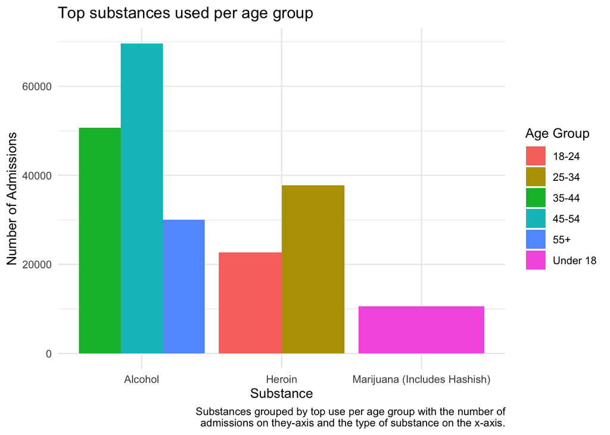

```r
ggplot(top_substance_df, aes(primary_substance_group, substance_count, fill = age_group)) +
  geom_bar(stat = "identity", position = "dodge") +
  scale_x_discrete(
    name = "Substance",
    labels = c(
      "All Others" = "Other",
      "Cocaine incl Crack" = "Cocaine (Includes Crack)",
      "Marijuana incl Hashish" = "Marijuana (Includes Hashish)"
    )
  ) +
  scale_fill_discrete(
    name = "Age Group",
    labels = c(
      "18 thru 24" = "18-24",
      "25 thru 34" = "25-34",
      "35 thru 44" = "35-44",
      "45 thru 54" = "45-54",
      "55 and Older" = "55+",
      "Under 18" = "Under 18"
    )
  ) +
  labs(
    y = "Number of Admissions",
    title = "Top substances used per age group",
    caption = "Substances grouped by top use per age group with the number of\nadmissions on they-axis and the type of substance on the x-axis."
  ) +
  theme(
    axis.title = element_text(face = "bold", color = "black")
  ) +
  theme_minimal()
```

```r
all_substance_df <- rehab_df %>%
  group_by(service_type, age_group, primary_substance_group) %>%
  # Take count to show how many admissions exist for each substance in each age group
  summarize(substance_count = sum(admissions)) %>%
  # Limit to age group
  group_by(age_group) %>%
  # Filter for the substances with the highest count
  mutate(substance_count == max(substance_count)) %>%
  # Show relevant columns
  select(service_type, age_group, primary_substance_group, substance_count)
all_substance_df
```

```
## # A tibble: 236 × 4
## # Groups:   age_group [6]
##    service_type             age_group  primary_substance_group substance_count
##    <fct>                    <fct>      <fct>                             <dbl>
##  1 Inpatient Rehabilitation 18 thru 24 Alcohol                           10949
##  2 Inpatient Rehabilitation 18 thru 24 All Others                         3234
##  3 Inpatient Rehabilitation 18 thru 24 Cocaine incl Crack                 4583
##  4 Inpatient Rehabilitation 18 thru 24 Heroin                            22705
##  5 Inpatient Rehabilitation 18 thru 24 Marijuana incl Hashish            10209
##  6 Inpatient Rehabilitation 18 thru 24 Other Opioids                      8718
##  7 Inpatient Rehabilitation 25 thru 34 Alcohol                           32121
##  8 Inpatient Rehabilitation 25 thru 34 All Others                         5640
##  9 Inpatient Rehabilitation 25 thru 34 Cocaine incl Crack                14559
## 10 Inpatient Rehabilitation 25 thru 34 Heroin                            37753
## # ℹ 226 more rows
```

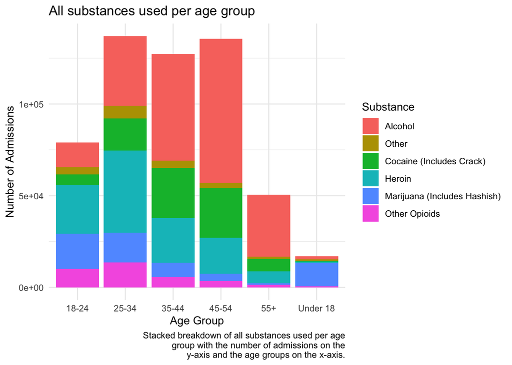

```r
ggplot(all_substance_df, aes(age_group, substance_count, fill = primary_substance_group)) +
  geom_bar(stat = "identity") +
  labs(
    x = "Age Group",
    y = "Number of Admissions",
    title = "All substances used per age group",
    caption = "Stacked breakdown of all substances used per age\ngroup with the number of admissions on the\ny-axis and the age groups on the x-axis."
  ) +
  scale_fill_discrete(
    name = "Substance",
    labels = c(
      "All Others" = "Other",
      "Cocaine incl Crack" = "Cocaine (Includes Crack)",
      "Marijuana incl Hashish" = "Marijuana (Includes Hashish)"
    )
  ) +
  scale_x_discrete(
    labels = c(
      "18 thru 24" = "18-24",
      "25 thru 34" = "25-34",
      "35 thru 44" = "35-44",
      "45 thru 54" = "45-54",
      "55 and Older" = "55+",
      "Under 18" = "Under 18"
    )
  ) +
  theme(
    axis.title = element_text(face = "bold", color = "black")
  ) +
  theme_minimal()
```

[figure not shown]

```r
ggplot(all_substance_df, aes(age_group, substance_count, fill = service_type)) +
  geom_bar(stat = "identity") +
  labs(
    x = "Age Group",
    y = "Number of Admissions",
    title = "Service used per age group",
    caption = "Stacked breakdown of services used for\nadmissions per age group with number of\nadmissions on the y-axis and age group on the y-axis."
  ) +
  scale_fill_discrete(
    name = "Service Type",
    labels = c(
      "Inpatient Rehabilitation" = "Inpatient",
      "Outpatient Rehabilitation" = "Outpatient",
      "Res Rehab for Youth" = "Youth Residential",
      "Residential Rehabilitation" = "Residential",
      "Specialized Services OP Rehab" = "Specialized Services OP"
    )
  ) +
  scale_x_discrete(
    labels = c(
      "18 thru 24" = "18-24",
      "25 thru 34" = "25-34",
      "35 thru 44" = "35-44",
      "45 thru 54" = "45-54",
      "55 and Older" = "55+",
      "Under 18" = "Under 18"
    )
  ) +
  theme(
    axis.title = element_text(face = "bold", color = "black")
  ) +
  theme_minimal()
```